# Breast cancer

Samuel Orso

2017-11-10

## Method

I run the panning (cf [our paper](http://journal.frontiersin.org/article/10.3389/fgene.2016.00097/full) and in the algorithm [implementation](https://github.com/samorso/panning2) ) on the dataset *Micro-RNA expression signatures in breast cancer progression* (see [here](https://www.ebi.ac.uk/arrayexpress/experiments/E-MTAB-3759/) ). This dataset has $n=156$ patients that we split into training and test sets, $n_{\text{Training}} = 130$ and $n_{\text{Test}}=26$. There are $p=15739$ RNA expressions per patients, we eliminate those with missing values so we worked with $p=14251$. We have experienced mitigated results with the original version of the panning. I tried two new version of the panning:

1. From the *first step* I screen only the variables below a given quantile $\hat{q}$ on the cross-validation errors (here I used $\hat{q}=0.00835$). I obtain a much small number of variables (here 118 remaining ones) that I save into a set, say $\mathcal{S}_1$. From these variables in $\mathcal{S}_1$, I construct exhaustively all possible models of size 2 (here 6903) and compute their CV errors. I save models with errors below the quantile $\hat{q}$ into $\mathcal{S}_2$. Then, for the rest of the algorithm, I iterate for $2< d<d_{\text{max}}$: I take the models in $\mathcal{S}_{d-1}$ and construct exhaustively all possible combination of models size $d$ by adding any (non-redundant) variables from $\mathcal{S}_1$. Hence only the first variables selected in $\mathcal{S}_1$ can potentially appears, all the other ones are discared.
2. From the *first step* I attribute to every unit (here variable) an individual probability of being selected $\pi_i,i=1,\dots,p$. This probability is defined as $\hat{\pi}_i = (\max{\text{CV}} - 1) / \max{\text{CV}}$, where $\max{\text{CV}}$ is the maximum CV error observed. The variables are stored in a set $\mathcal{S}$ with associated probabilities set $\mathcal{P}$. Then, for the rest of the algorithm, I iterate for $2\leq d<d_{\text{max}}$: I construct a model of size $d$ by drawing units from $\mathcal{S}$ with probability in $\mathcal{P}$, and evaluate its CV error, repeat $B$ times (here $B=10^4$); the set $\mathcal{S}$ is augmented with $B$ new units (now models of size $d$) and the probabilities are all reevaluated in $\mathcal{P}$.

Remark:

- The *first step* is an exhaustive computation of all cross-validation for each individual variables.
- For both versions of the algorithm I stop at $d_{\text{max}} = 15$.

## Results of the algorithm

I represent boxplot of the CV errors of the selected models and the related testing error (unknown a prior). Here are the results with the first version of the panning:

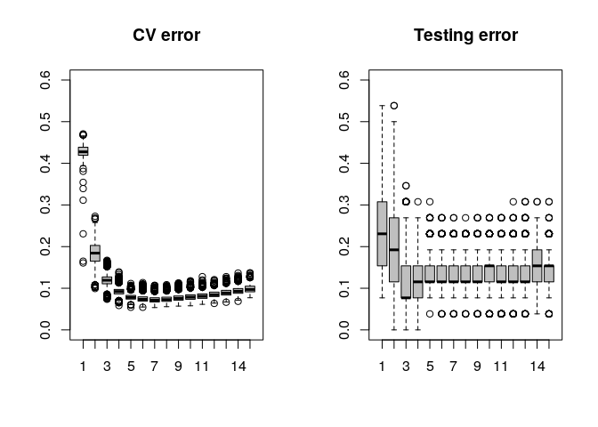

```r
load("~/Documents/Projects/Panning/bc/Testing.rda")
cvs1 <- vector("list",15)
for(i in 1:15){
  cvs1[[i]] <- Testing[[i]][,1]
}
tes1 <- vector("list",15)
for(i in 1:15){
  tes1[[i]] <- 1-Testing[[i]][,6]
}

par(mfrow=c(1,2))
boxplot(cvs1,col="gray75",main="CV error",ylim=c(0,.6))
boxplot(tes1,col="gray75",main="Testing error",ylim=c(0,.6))
```

We can remark:

- We observe the ‘Nike’ sign.
- CV errors seem not too accurate as an estimate of the testing error.

And now the second version:

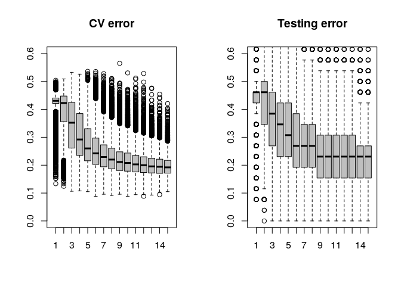

```r
load("~/Documents/Projects/Panning/bc/Testing2.rda")
dmax <- 15
cvs2 <- vector("list",dmax)
for(i in 1:dmax){
  cvs2[[i]] <- Testing[[i]][,1]
}
tes2 <- vector("list",dmax)
for(i in 1:dmax){
  tes2[[i]] <- 1-Testing[[i]][,6]
}

par(mfrow=c(1,2))
boxplot(cvs2,col="gray75",main="CV error",ylim=c(0,.6))
boxplot(tes2,col="gray75",main="Testing error",ylim=c(0,.6))
```

We can remark:

- Much more variability in CV and testing errors compare to version 1 (more variables).
- CV errors decreasing slower than version 1.

A compromise between these two versions might be a good option for future research.

## Main results

I keep arbitrarly models with CV errors below 6% (the observed minimum being approx. 5.36%). This level excludes result from the version 2 of the panning (observed minimum at 8.78%).

Graphically, it means we are taking the following shaded area:

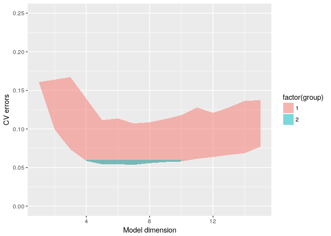

```r
id_x <- which(sapply(cvs1,function(x)sum(x<.06))!=0)
y_1 <- c(sapply(cvs1,max),sapply(cvs1,min)[dmax:1])
y_2 <- rep(NA, 2 * length(id_x))
for(i in seq_along(id_x)){
  y_2[2 * i - 1] <- 6e-2
  y_2[2 * i] <- min(cvs1[[id_x[i]]])
}

x_1 <- c(1:15,15:1)
x_2 <- c(id_x,sort(id_x,decreasing=T))
y_2 <- y_2[c(seq(1,length(id_x)*2,2),seq(length(id_x)*2,2,-2))]

require(ggplot2)
d_f <- data.frame(
  y = c(y_1,y_2),
  x = c(x_1,x_2),
  group = c(rep(1,2 * dmax),rep(2,2*length(id_x)))
)

ggplot(data = d_f, aes(x = x, y = y)) +
  geom_polygon(aes(fill = factor(group), group = factor(group)), alpha = .5) +
  ylim(c(0,.25)) + xlab("Model dimension") + ylab("CV errors")
```

```r
load("~/Documents/Projects/Panning/bc/Testing.rda")
load("~/Documents/Projects/Panning/bc/VarMat.rda")
id <- vector("list",dmax)
for(i in seq_len(dmax)){
  id[[i]] <- which(Testing[[i]][,1]<.06)
}
it <- which(sapply(id,length)!=0)
models <- vector("list",length(it))
perf <- NULL
for(i in seq_along(it)){
  perf <- rbind(perf,Testing[[it[i]]][id[[it[i]]],])
  models[[i]] <- VarMat[[it[i]]][id[[it[i]]],]
}
```

We have 165 models for 67 different variables. Here is a barplot of the number of appearance of each variables

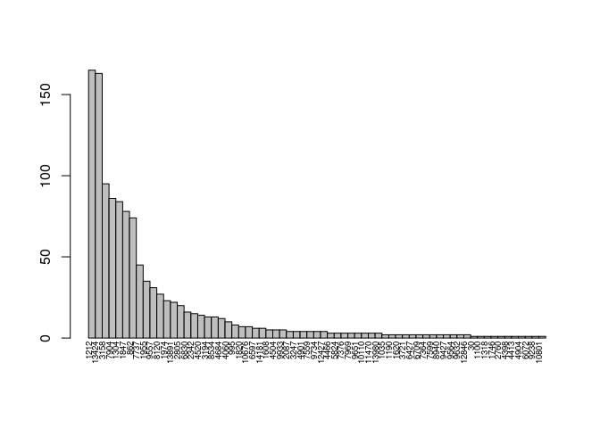

```r
tbl <- sort(table(unlist(models)),decreasing = TRUE)
barplot(tbl, names.arg = "", space = 0)
text(x=seq_along(tbl)-1,y=-2,srt=90,adj=1,labels=names(tbl),xpd=T,cex = .6)
```

```r
tbl[tbl >= 10]
```

```
##
##  1212 13424  3158  7904  1304  1847   862  7737  1955  9557  8120  1974
##   165   163    95    86    84    78    74    45    35    31    27    23
## 13891  2805  6830  2342  4520  3194  8534  4684  4060
##    22    20    16    15    14    13    13    12    10
```

We can display the different models with the following graph networks:

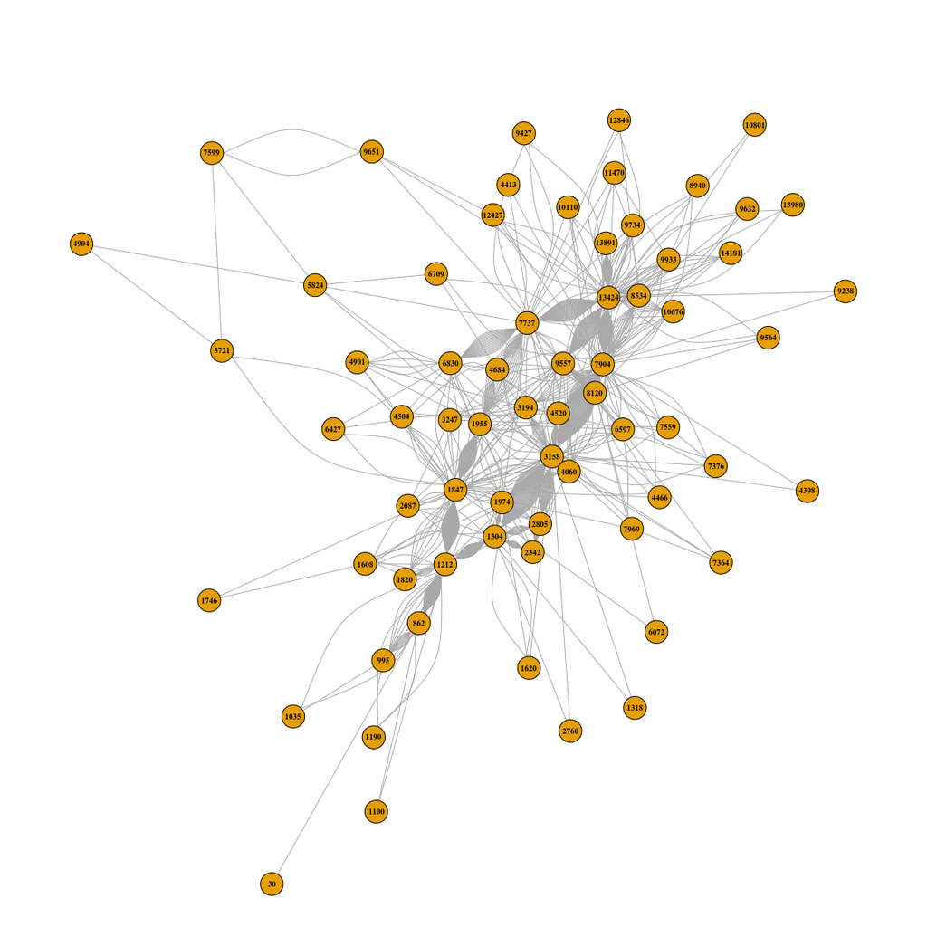

```r
require(igraph)
variables_2_2 <- matrix(nr = sum(sapply(models,length)/it * (it-1)), nc = 2)
ind <- 1
for(i in seq_along(models)){
  mod <- models[[i]]
  if(is.null(nrow(mod))){
    mat <- matrix(mod[c(seq_len(length(mod)-1),seq.int(2,length(mod)))],
                  nr = length(mod)-1, nc = 2)
  }else{
    mat <- matrix(mod[1L:nrow(mod),c(seq_len(ncol(mod)-1),seq.int(2,ncol(mod)))],
                  nr = nrow(mod)*(ncol(mod)-1), nc = 2)
  }
  variables_2_2[ind:(ind+nrow(mat)-1),] <- mat
  ind <- ind + nrow(mat)
}
network <- graph_from_data_frame(d = variables_2_2, directed = F)
par(mai=c(0,0,1,0))
plot.igraph(network,
            layout=layout.fruchterman.reingold, #the layout method. see the igraph documentation for details
            vertex.frame.color='black',           #the color of the border of the dots
            vertex.label.color='black',     #the color of the name labels
            vertex.label.font=2,        #the font of the name labels
            vertex.label.cex=.6,        #specifies the size of the font of the labels. can also be made to vary
            vertex.size = 6
)
```

We can summarize the performances the models by this tabular:

```r
d_f <- data.frame(
  measure = c(perf[,1],perf[,6],perf[,7],perf[,8]),
  groups = c(rep("CV error",nrow(perf)),rep("Testing accuracy",nrow(perf)),
             rep("Specificity",nrow(perf)),rep("Sensitivity",nrow(perf)))
)
require(dplyr)
d_f %>% group_by(groups) %>% summarise(Average = mean(measure), Median = median(measure), Std_dev = sd(measure), Min = min(measure), Max = max(measure))
```

| groups | Average | Median | Std_dev | Min | Max |
| --- | --- | --- | --- | --- | --- |
| CV error | 0.0582208 | 0.0585714 | 0.0014102 | 0.0535714 | 0.0600000 |
| Sensitivity | 0.8911269 | 0.9090909 | 0.0342824 | 0.7857143 | 0.9166667 |
| Specificity | 0.8782973 | 0.8666667 | 0.0341274 | 0.8000000 | 0.9285714 |
| Testing accuracy | 0.8825175 | 0.8846154 | 0.0259244 | 0.8076923 | 0.9230769 |

The heatmap is quite nice in this case, we can see quite a clear difference between patients.

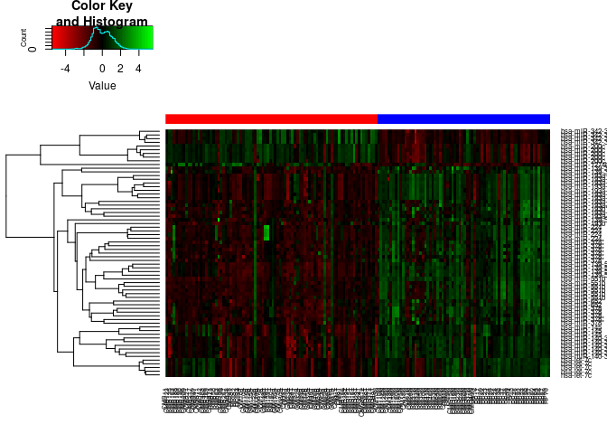

```r
id_var <- unique(unlist(models))
load("~/Documents/Projects/Panning/x.rda")
load("~/Documents/Projects/Panning/y.rda")
load("~/Documents/Projects/Panning/bc/names.rda")
htmp <- x[,id_var]
colnames(htmp) <- names[id_var,8]
require(gplots)
patients_col <- c(rep("red",sum(y==0)),rep("blue",sum(y==1)))
heatmap.2(t(scale(htmp)), col=redgreen(75), trace="none", ColSideColors = patients_col,
          scale="none", dendrogram = "row", Colv=F)
```

Here are the informations about the 67 variables:

```r
id_var <- sort(id_var)
var_names <- names[id_var,-c(1:3,5,6,9,10)]
rownames(var_names) <- id_var
var_names
```

|  | Sequence | ProbeName | GeneName |
| --- | --- | --- | --- |
| 30 | CTGAAACCAAGTATGGGTCGC | A_25_P00014894 | hsa-miR-551b |
| 862 | CTGGAGACACGTGCAC | A_25_P00012071 | hsa-miR-139-5p |
| 995 | AACCATACAACCTACTACC | A_25_P00010072 | hsa-let-7c |
| 1035 | TCATCTCGCCCGC | A_25_P00012254 | hsa-miR-193a-5p |
| 1100 | TCATCTCGCCCTC | A_25_P00013597 | hsa-miR-193b* |
| 1190 | TCCATCATTACCCGG | A_25_P00012266 | hsa-miR-200c |
| 1212 | TGGCGCCCGAACA | A_25_P00015231 | hsa-miR-1274b |
| 1304 | ACGGGTGCGATTTCTG | A_25_P00012358 | hsa-miR-342-3p |
| 1318 | CCGTGGTTCTACCCT | A_25_P00012177 | hsa-miR-140-3p |
| 1608 | TCATCTCGCCCGC | A_25_P00012254 | hsa-miR-193a-5p |
| 1620 | CTGAAACCAAGTATGGGTCG | A_25_P00014215 | hsa-miR-551b |
| 1746 | AGGGATTCCTGGGAAAAC | A_25_P00012193 | hsa-miR-145 |
| 1820 | CCGTGGTTCTACCCT | A_25_P00012177 | hsa-miR-140-3p |
| 1847 | ACGGGTGCGATTTCTG | A_25_P00012358 | hsa-miR-342-3p |
| 1955 | TCATCTCGCCCG | A_25_P00012253 | hsa-miR-193a-5p |
| 1974 | CCGTGGTTCTACCCT | A_25_P00012177 | hsa-miR-140-3p |
| 2087 | TCATCTCGCCCGC | A_25_P00012254 | hsa-miR-193a-5p |
| 2342 | TCATCTCGCCCG | A_25_P00012253 | hsa-miR-193a-5p |
| 2760 | CCTTCTGACTCCA | A_25_P00012333 | hsa-miR-378 |
| 2805 | CCTTCTGACTCCA | A_25_P00012333 | hsa-miR-378 |
| 3158 | CTGGAGACACGTGCAC | A_25_P00012071 | hsa-miR-139-5p |
| 3194 | AACCATACAACCTACTACC | A_25_P00010072 | hsa-let-7c |
| 3247 | AGGGATTCCTGGGAAAA | A_25_P00012192 | hsa-miR-145 |
| 3721 | AGCGGGACTTTGAGG | A_25_P00012511 | hsa-miR-193b |
| 4060 | AACGGAACCACTAGTGACTT | A_25_P00012134 | hsa-miR-224 |
| 4398 | CTGGAGACACGTGCAC | A_25_P00012071 | hsa-miR-139-5p |
| 4413 | ACGGGTGCGATTTCTG | A_25_P00012358 | hsa-miR-342-3p |
| 4466 | ACACAGGACCTGGAGTCA | A_25_P00014621 | hsa-miR-378* |
| 4504 | AGGGATTCCTGGGAAAAC | A_25_P00012193 | hsa-miR-145 |
| 4520 | TCATCTCGCCCG | A_25_P00012253 | hsa-miR-193a-5p |
| 4684 | CTGAAACCAAGTATGGGTCG | A_25_P00014215 | hsa-miR-551b |
| 4901 | ACACAGGACCTGGAGTCA | A_25_P00014621 | hsa-miR-378* |
| 4904 | ACTCCAACAGGGCCG | A_25_P00012074 | hsa-miR-139-3p |
| 5824 | ACTCCAACAGGGCCG | A_25_P00012074 | hsa-miR-139-3p |
| 6072 | TCATCTCGCCCGC | A_25_P00012254 | hsa-miR-193a-5p |
| 6427 | CACAACCCTAGTGGC | A_25_P00012834 | hsa-miR-652 |
| 6597 | CCGTGGTTCTACCCT | A_25_P00012177 | hsa-miR-140-3p |
| 6709 | TCATCTCGCCCG | A_25_P00012253 | hsa-miR-193a-5p |
| 6830 | TCATCTCGCCCGC | A_25_P00012254 | hsa-miR-193a-5p |
| 7364 | ACACAGGACCTGGAGTC | A_25_P00014620 | hsa-miR-378* |
| 7376 | ACGGGTGCGATTTCTG | A_25_P00012358 | hsa-miR-342-3p |
| 7559 | TCCATCATTACCCGG | A_25_P00012266 | hsa-miR-200c |
| 7599 | CTGGAGACACGTGCAC | A_25_P00012071 | hsa-miR-139-5p |
| 7737 | ACACAGGACCTGGAGTC | A_25_P00014620 | hsa-miR-378* |
| 7904 | ACACAGGACCTGGAGTCA | A_25_P00014621 | hsa-miR-378* |
| 7969 | TCATCTCGCCCGC | A_25_P00012254 | hsa-miR-193a-5p |
| 8120 | CCGTGGTTCTACCCT | A_25_P00012177 | hsa-miR-140-3p |
| 8534 | CTGAAACCAAGTATGGGTCG | A_25_P00014215 | hsa-miR-551b |
| 8940 | CCGTGGTTCTACCCT | A_25_P00012177 | hsa-miR-140-3p |
| 9238 | CTGAAACCAAGTATGGGTCG | A_25_P00014215 | hsa-miR-551b |
| 9427 | TCCATCATTACCCGG | A_25_P00012266 | hsa-miR-200c |
| 9557 | ACACAGGACCTGGAGTCA | A_25_P00014621 | hsa-miR-378* |
| 9564 | ACACAGGACCTGGAGTCA | A_25_P00014621 | hsa-miR-378* |
| 9632 | AACGGAACCACTAGTGACTT | A_25_P00012134 | hsa-miR-224 |
| 9651 | CACAACCCTAGTGGC | A_25_P00012834 | hsa-miR-652 |
| 9734 | AACGGAACCACTAGTGACT | A_25_P00012133 | hsa-miR-224 |
| 9933 | CTGAAACCAAGTATGGGTCG | A_25_P00014215 | hsa-miR-551b |
| 10110 | ACACAGGACCTGGAGTC | A_25_P00014620 | hsa-miR-378* |
| 10676 | CCTTCTGACTCCA | A_25_P00012333 | hsa-miR-378 |
| 10801 | TCCATCATTACCCGG | A_25_P00012266 | hsa-miR-200c |
| 11470 | TCATCTCGCCCGC | A_25_P00012254 | hsa-miR-193a-5p |
| 12427 | CTGGAGACACGTGCA | A_25_P00012070 | hsa-miR-139-5p |
| 12846 | AACCATACAACCTACTACC | A_25_P00010072 | hsa-let-7c |
| 13424 | AACGGAACCACTAGTGACT | A_25_P00012133 | hsa-miR-224 |
| 13891 | AACCATACAACCTACTACC | A_25_P00010072 | hsa-let-7c |
| 13980 | AACCATACAACCTACTACC | A_25_P00010072 | hsa-let-7c |
| 14181 | TCCATCATTACCCGG | A_25_P00012266 | hsa-miR-200c |

New names for variables (thanks to Nabil):

```r
var_names_new <- read.csv(file="~/Documents/Projects/Panning/bc/new_var_names.csv", header = F, colClasses = "character",nrows=67,col.names="NewGeneName")
var_names2 <- data.frame(
  Sequence = var_names[,1],
  ProbeName = var_names[,2],
  GeneName = var_names[,3],
  NewGeneName = var_names_new
)
var_names2
```

| Sequence | ProbeName | GeneName | NewGeneName |
| --- | --- | --- | --- |
| CTGAAACCAAGTATGGGTCGC | A_25_P00014894 | hsa-miR-551b | hsa-miR-551b |
| CTGGAGACACGTGCAC | A_25_P00012071 | hsa-miR-139-5p | hsa-miR-139-5p |
| AACCATACAACCTACTACC | A_25_P00010072 | hsa-let-7c | hsa-let-7c |
| TCATCTCGCCCGC | A_25_P00012254 | hsa-miR-193a-5p | hsa-miR-193a-5p |
| TCATCTCGCCCTC | A_25_P00013597 | hsa-miR-193b* | hsa-miR-193b-5p |
| TCCATCATTACCCGG | A_25_P00012266 | hsa-miR-200c | hsa-miR-200c |
| TGGCGCCCGAACA | A_25_P00015231 | hsa-miR-1274b | Lys tRNA |
| ACGGGTGCGATTTCTG | A_25_P00012358 | hsa-miR-342-3p | hsa-miR-342-3p |
| CCGTGGTTCTACCCT | A_25_P00012177 | hsa-miR-140-3p | hsa-miR-140-3p |
| TCATCTCGCCCGC | A_25_P00012254 | hsa-miR-193a-5p | hsa-miR-193a-5p |
| CTGAAACCAAGTATGGGTCG | A_25_P00014215 | hsa-miR-551b | hsa-miR-551b |
| AGGGATTCCTGGGAAAAC | A_25_P00012193 | hsa-miR-145 | hsa-miR-145 |
| CCGTGGTTCTACCCT | A_25_P00012177 | hsa-miR-140-3p | hsa-miR-140-3p |
| ACGGGTGCGATTTCTG | A_25_P00012358 | hsa-miR-342-3p | hsa-miR-342-3p |
| TCATCTCGCCCG | A_25_P00012253 | hsa-miR-193a-5p | hsa-miR-193a-5p |
| CCGTGGTTCTACCCT | A_25_P00012177 | hsa-miR-140-3p | hsa-miR-140-3p |
| TCATCTCGCCCGC | A_25_P00012254 | hsa-miR-193a-5p | hsa-miR-193a-5p |
| TCATCTCGCCCG | A_25_P00012253 | hsa-miR-193a-5p | hsa-miR-193a-5p |
| CCTTCTGACTCCA | A_25_P00012333 | hsa-miR-378 | hsa-mir-378a |
| CCTTCTGACTCCA | A_25_P00012333 | hsa-miR-378 | hsa-mir-378a |
| CTGGAGACACGTGCAC | A_25_P00012071 | hsa-miR-139-5p | hsa-miR-139-5p |
| AACCATACAACCTACTACC | A_25_P00010072 | hsa-let-7c | hsa-let-7c |
| AGGGATTCCTGGGAAAA | A_25_P00012192 | hsa-miR-145 | hsa-miR-145 |
| AGCGGGACTTTGAGG | A_25_P00012511 | hsa-miR-193b | hsa-miR-193b |
| AACGGAACCACTAGTGACTT | A_25_P00012134 | hsa-miR-224 | hsa-miR-224 |
| CTGGAGACACGTGCAC | A_25_P00012071 | hsa-miR-139-5p | hsa-miR-139-5p |
| ACGGGTGCGATTTCTG | A_25_P00012358 | hsa-miR-342-3p | hsa-miR-342-3p |
| ACACAGGACCTGGAGTCA | A_25_P00014621 | hsa-miR-378* | hsa-miR-378a-5p |
| AGGGATTCCTGGGAAAAC | A_25_P00012193 | hsa-miR-145 | hsa-miR-145 |
| TCATCTCGCCCG | A_25_P00012253 | hsa-miR-193a-5p | hsa-miR-193a-5p |
| CTGAAACCAAGTATGGGTCG | A_25_P00014215 | hsa-miR-551b | hsa-miR-551b |
| ACACAGGACCTGGAGTCA | A_25_P00014621 | hsa-miR-378* | hsa-miR-378a-5p |
| ACTCCAACAGGGCCG | A_25_P00012074 | hsa-miR-139-3p | hsa-miR-139-3p |
| ACTCCAACAGGGCCG | A_25_P00012074 | hsa-miR-139-3p | hsa-miR-139-3p |
| TCATCTCGCCCGC | A_25_P00012254 | hsa-miR-193a-5p | hsa-miR-193a-5p |
| CACAACCCTAGTGGC | A_25_P00012834 | hsa-miR-652 | hsa-miR-652 |
| CCGTGGTTCTACCCT | A_25_P00012177 | hsa-miR-140-3p | hsa-miR-140-3p |
| TCATCTCGCCCG | A_25_P00012253 | hsa-miR-193a-5p | hsa-miR-193a-5p |
| TCATCTCGCCCGC | A_25_P00012254 | hsa-miR-193a-5p | hsa-miR-193a-5p |
| ACACAGGACCTGGAGTC | A_25_P00014620 | hsa-miR-378* | hsa-miR-378a-5p |
| ACGGGTGCGATTTCTG | A_25_P00012358 | hsa-miR-342-3p | hsa-miR-342-3p |
| TCCATCATTACCCGG | A_25_P00012266 | hsa-miR-200c | hsa-miR-200c |
| CTGGAGACACGTGCAC | A_25_P00012071 | hsa-miR-139-5p | hsa-miR-139-5p |
| ACACAGGACCTGGAGTC | A_25_P00014620 | hsa-miR-378* | hsa-miR-378a-5p |
| ACACAGGACCTGGAGTCA | A_25_P00014621 | hsa-miR-378* | hsa-miR-378a-5p |
| TCATCTCGCCCGC | A_25_P00012254 | hsa-miR-193a-5p | hsa-miR-193a-5p |
| CCGTGGTTCTACCCT | A_25_P00012177 | hsa-miR-140-3p | hsa-miR-140-3p |
| CTGAAACCAAGTATGGGTCG | A_25_P00014215 | hsa-miR-551b | hsa-miR-551b |
| CCGTGGTTCTACCCT | A_25_P00012177 | hsa-miR-140-3p | hsa-miR-140-3p |
| CTGAAACCAAGTATGGGTCG | A_25_P00014215 | hsa-miR-551b | hsa-miR-551b |
| TCCATCATTACCCGG | A_25_P00012266 | hsa-miR-200c | hsa-miR-200c |
| ACACAGGACCTGGAGTCA | A_25_P00014621 | hsa-miR-378* | hsa-miR-378a-5p |
| ACACAGGACCTGGAGTCA | A_25_P00014621 | hsa-miR-378* | hsa-miR-378a-5p |
| AACGGAACCACTAGTGACTT | A_25_P00012134 | hsa-miR-224 | hsa-miR-224 |
| CACAACCCTAGTGGC | A_25_P00012834 | hsa-miR-652 | hsa-miR-652 |
| AACGGAACCACTAGTGACT | A_25_P00012133 | hsa-miR-224 | hsa-miR-224 |
| CTGAAACCAAGTATGGGTCG | A_25_P00014215 | hsa-miR-551b | hsa-miR-551b |
| ACACAGGACCTGGAGTC | A_25_P00014620 | hsa-miR-378* | hsa-miR-378a-5p |
| CCTTCTGACTCCA | A_25_P00012333 | hsa-miR-378 | hsa-mir-378a |
| TCCATCATTACCCGG | A_25_P00012266 | hsa-miR-200c | hsa-miR-200c |
| TCATCTCGCCCGC | A_25_P00012254 | hsa-miR-193a-5p | hsa-miR-193a-5p |
| CTGGAGACACGTGCA | A_25_P00012070 | hsa-miR-139-5p | hsa-miR-139-5p |
| AACCATACAACCTACTACC | A_25_P00010072 | hsa-let-7c | hsa-let-7c |
| AACGGAACCACTAGTGACT | A_25_P00012133 | hsa-miR-224 | hsa-miR-224 |
| AACCATACAACCTACTACC | A_25_P00010072 | hsa-let-7c | hsa-let-7c |
| AACCATACAACCTACTACC | A_25_P00010072 | hsa-let-7c | hsa-let-7c |
| TCCATCATTACCCGG | A_25_P00012266 | hsa-miR-200c | hsa-miR-200c |

Here a barplot according to the new variable names:

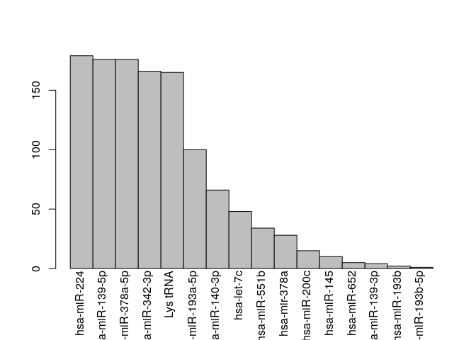

```r
id_var_code <- c(var_names_new = id_var)
names(id_var_code) = var_names_new$NewGeneName
models2 <- models
for(i in seq_along(models)){
  dm <- dim(models[[i]])
  if(is.null(dm)){
    dm <- c(1,length(models[[i]]))
  }
  models2[[i]] <- matrix(names(id_var_code)[match(models[[i]],id_var_code)],nr=dm[1],nc=dm[2])
}
tbl <- sort(table(unlist(models2)),decreasing = TRUE)
barplot(tbl, names.arg = "", space = 0)
text(x=seq_along(tbl)-.6,y=-2,srt=90,adj=1,labels=names(tbl),xpd=T,cex = 1)
```

… and a network graph:

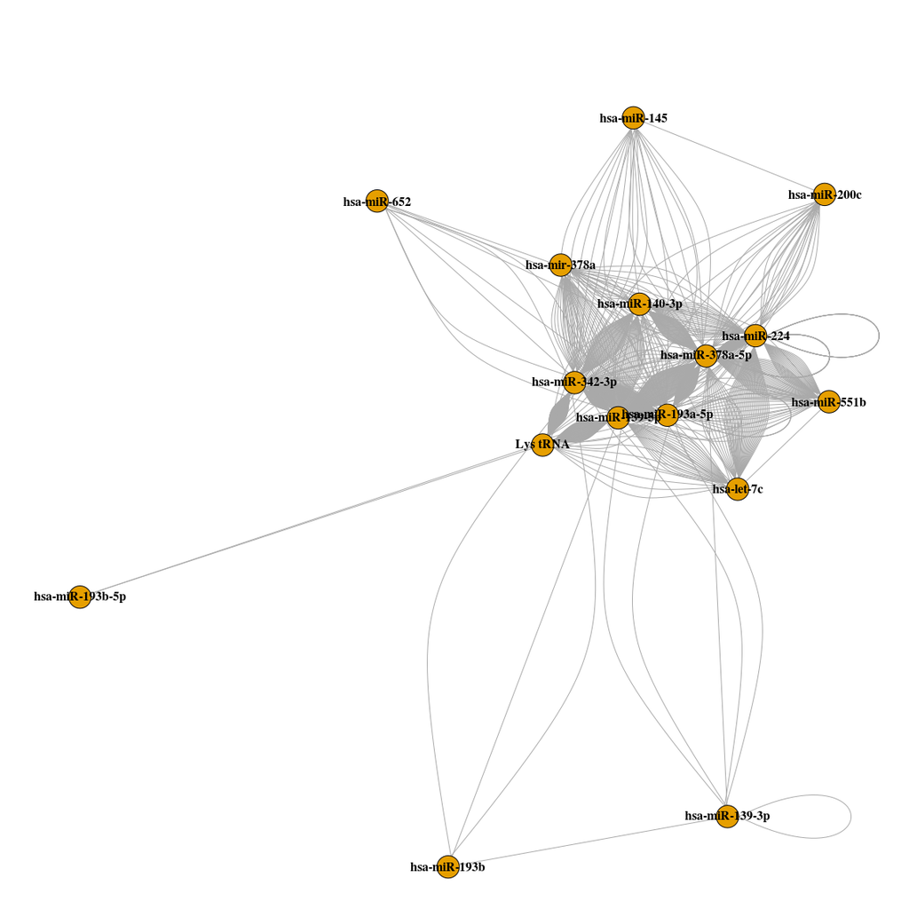

```r
require(igraph)
variables_2_2 <- matrix(nr = sum(sapply(models2,length)/it * (it-1)), nc = 2)
ind <- 1
for(i in seq_along(models2)){
  mod <- models2[[i]]
  if(is.null(nrow(mod))){
    mat <- matrix(mod[c(seq_len(length(mod)-1),seq.int(2,length(mod)))],
                  nr = length(mod)-1, nc = 2)
  }else{
    mat <- matrix(mod[1L:nrow(mod),c(seq_len(ncol(mod)-1),seq.int(2,ncol(mod)))],
                  nr = nrow(mod)*(ncol(mod)-1), nc = 2)
  }
  variables_2_2[ind:(ind+nrow(mat)-1),] <- mat
  ind <- ind + nrow(mat)
}
network <- graph_from_data_frame(d = variables_2_2, directed = F)
par(mai=c(0,0,1,0))
plot.igraph(network,
            layout=layout.fruchterman.reingold, #the layout method. see the igraph documentation for details
            vertex.frame.color='black',           #the color of the border of the dots
            vertex.label.color='black',     #the color of the name labels
            vertex.label.font=2,        #the font of the name labels
            vertex.label.cex=1,     #specifies the size of the font of the labels. can also be made to vary
            vertex.size = 6
)
```